# Tutorial for heritability estimate and computing genetic correlation in GXwasR R package.

By Banabithi Bose

11/13/2023

# Contents

**This document provides a tutorial for heritability estimate and computing genetic correlation utilizing GXwasR R package.**

```r
## Call some libraries
library(GXwasR)
library(printr)
library(rmarkdown)
## Load the example .Rda files
data("GXwasRData")
```

# 1 Computing heritability estimate using EstimateHerit():

```r
help(EstimateHerit, package = GXwasR)
```

| EstimateHerit | R Documentation |
| --- | --- |

## EstimateHerit: Computing SNP heritability i.e., the proportion of phenotypic variance explained by SNPs.

### Description

This functions performs two types of heritability estimation, (i)GREML:Genomic relatedness matrix (GRM) restricted maximum likelihood-based method following GCTA (1) and (ii)LDSC: LD score regression-based method following (2,3). For the details, please follow the associated paper.

Prior using this function, users are recommended to apply QCsnp and QCsample to ensure data quality control.

### Usage

```r
EstimateHerit(
  DataDir,
  ResultDir,
  finput,
  summarystat = NULL,
  ncores = 0,
  model = c("LDSC", "GREML"),
  byCHR = FALSE,
  r2_LD = 0,
  LDSC_blocks = 20,
  REMLalgo = c(0, 1, 2),
  nitr = 100,
  cat_covarfile = NULL,
  quant_covarfile = NULL,
  prevalance = 0.01,
  partGRM = FALSE,
  autosome = TRUE,
  Xsome = TRUE,
  nGRM = 3,
  cripticut = 0.025,
  minMAF = NULL,
  maxMAF = NULL,
  hg = c("hg19", "hg38"),
  PlotIndepSNP = c(TRUE, FALSE),
  IndepSNP_window_size = 50,
  IndepSNP_step_size = 5,
  IndepSNP_r2_threshold = 0.02,
  highLD_regions = NULL
)
```

### Arguments

[output not shown]

### References

(1) Yang et al. (2011) GCTA: a tool for Genome-wide Complex Trait Analysis. Am J Hum Genet. 88(1): 76-82.

(2) Bulik-Sullivan B, et al. LD score regression distinguishes confounding from polygenicity in genome-wide association studies. Nat Genet. 2014;47:291–295.

(3) Florian Privé, Julyan Arbel, Bjarni J Vilhjálmsson, LDpred2: better, faster, stronger, Bioinformatics, Volume 36, Issue 22-23, 1 December 2020, Pages 5424–5431, https://doi.org/10.1093/bioinformatics/btaa1029

### Examples

```r
#Not Run
```

## 1.1 Running EstimateHerit() with model = “GREML”

```r
# Running
DataDir = system.file("extdata", package = "GXwasR")
#ResultDir = tempdir()
ResultDir <- "/projects/b1137/BBose/Herit"
finput <- "GXwasR_example"
ncores = 3
model = "GREML"
byCHR = FALSE
r2_LD = 0
LDSC_blocks = 20
REMLalgo = 0
nitr = 100
cat_covarfile = NULL
quant_covarfile = NULL
prevalance = 0.01
partGRM = FALSE
autosome = TRUE
Xsome = TRUE
nGRM = 3
cripticut = 0.025
minMAF = NULL
maxMAF = NULL
hg = "hg19"
byCHR = TRUE
PlotIndepSNP = TRUE
IndepSNP_window_size = 50
IndepSNP_step_size = 5
IndepSNP_r2_threshold = 0.02

# For saving the plot in .jpeg file, make plotjpeg = TRUE.

source("/home/bbj5535/b1137/BBose/GXwasR/R/GXwasR_main_functions.R")
source("/home/bbj5535/b1137/BBose/GXwasR/R/GXwasR_helper_functions.R")

H2 <- EstimateHerit(DataDir = DataDir, ResultDir = ResultDir, finput = finput, summarystat = NULL, ncores = 5, model = model, byCHR = TRUE, r2_LD = 0, LDSC_blocks = 20,REMLalgo = 0, nitr = nitr, cat_covarfile = NULL, quant_covarfile = NULL,prevalance = 0.01, partGRM = FALSE, autosome = TRUE, Xsome = TRUE, nGRM = 3, computeGRM = TRUE, grmfile_name = NULL, cripticut = 0.025, minMAF = NULL, maxMAF = NULL,hg = "hg19",PlotIndepSNP = TRUE, IndepSNP_window_size = 50,IndepSNP_step_size = 5,IndepSNP_r2_threshold = 0.02,highLD_regions = highLD_hg19, plotjpeg = FALSE, plotname = "Heritability_Plots")
```

```
## [1] "Program is set up."
## [1] "GCTA setup complete. This program is currently only supported in Linux."
## [1] "Processing chromosome 1"
## [1] "Processing chromosome 2"
## [1] "Processing chromosome 3"
## [1] "Processing chromosome 4"
## [1] "Processing chromosome 5"
## [1] "Processing chromosome 6"
## [1] "Processing chromosome 7"
## [1] "Processing chromosome 8"
## [1] "Convergence issue occurs, please check the models, use byCHR = TRUE, check different options, SNP partitioning or quality of the data"
## Reading IDs of the GRM from [/projects/b1137/BBose/Herit/GXwasR.grm.id].
## 276 IDs are read from [/projects/b1137/BBose/Herit/GXwasR.grm.id].
## Reading the GRM from [/projects/b1137/BBose/Herit/GXwasR.grm.bin].
## GRM for 276 individuals are included from [/projects/b1137/BBose/Herit/GXwasR.grm.bin].
```

[output cut: 128 more lines]

```r
#Heritability
H2
```

[output not shown]

## 1.2 Running the EstimateHerit() by providing chromosome-wise GRM files in ResultDir

Set:

computeGRM = FALSE

grmfile_name = “GXwasR”…… This is the prefix. These files are created in the previous run in ResultDir. Users are encouraged to check that folder.

```
## [1] "Program is set up."
## [1] "GCTA setup complete. This program is currently only supported in Linux."
## [1] "Processing chromosome 1"
## [1] "Processing chromosome 2"
## [1] "Processing chromosome 3"
## [1] "Processing chromosome 4"
## [1] "Processing chromosome 5"
## [1] "Processing chromosome 6"
## [1] "Processing chromosome 7"
## [1] "Processing chromosome 8"
## [1] "Convergence issue occurs, please check the models, use byCHR = TRUE, check different options, SNP partitioning or quality of the data"
## Reading IDs of the GRM from [/projects/b1137/BBose/Herit/Chr8_GXwasR.grm.id].
## 276 IDs are read from [/projects/b1137/BBose/Herit/Chr8_GXwasR.grm.id].
## Reading the GRM from [/projects/b1137/BBose/Herit/Chr8_GXwasR.grm.bin].
## GRM for 276 individuals are included from [/projects/b1137/BBose/Herit/Chr8_GXwasR.grm.bin].
```

[output cut: 133 more lines]

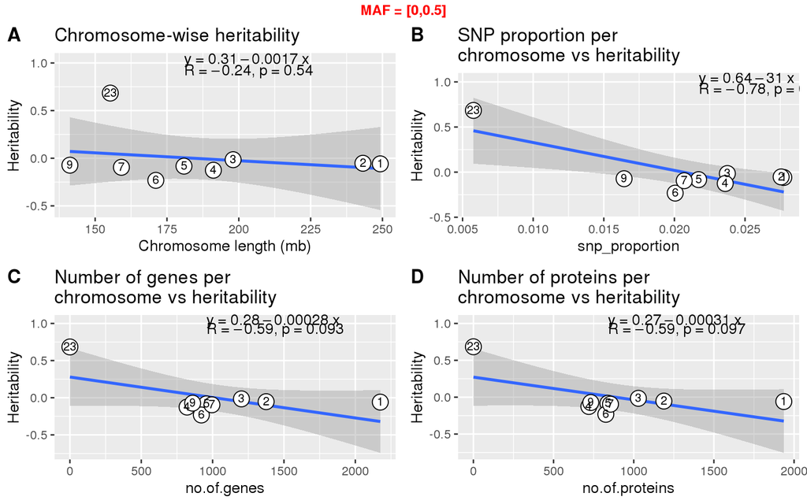

```
## [1] "All GRM related files are in /projects/b1137/BBose/Herit"
```

```r
source("/projects/b1137/BBose/GXwasR/R/GXwasR_main_functions.R")
source("/projects/b1137/BBose/GXwasR/R/GXwasR_helper_functions.R")

H2 <- EstimateHerit(DataDir = DataDir, ResultDir = ResultDir, finput = finput, summarystat = NULL, ncores = 5, model = model, byCHR = TRUE, r2_LD = 0, LDSC_blocks = 20,REMLalgo = 0, nitr = nitr, cat_covarfile = NULL, quant_covarfile = NULL,prevalance = 0.01, partGRM = FALSE, autosome = TRUE, Xsome = TRUE, nGRM = 3, computeGRM = FALSE, grmfile_name = "GXwasR", cripticut = 0.025, minMAF = NULL, maxMAF = NULL,hg = "hg19",PlotIndepSNP = TRUE, IndepSNP_window_size = 50,IndepSNP_step_size = 5,IndepSNP_r2_threshold = 0.02,highLD_regions = highLD_hg19, plotjpeg = FALSE, plotname = "Heritability_Plots")
```

```r
#Heritability
H2
```

| Chromosome | SNP_proportion | No.of.genes | No.of.proteins | Size_mb | Source | Variance | SE |
| --- | --- | --- | --- | --- | --- | --- | --- |
| 1 | 0.0277453 | 2175 | 1936 | 249.25062 | V(G) | -0.014132 | 0.053414 |
| 1 | 0.0277453 | 2175 | 1936 | 249.25062 | V(e) | 0.253334 | 0.058554 |
| 1 | 0.0277453 | 2175 | 1936 | 249.25062 | Vp | 0.239202 | 0.020425 |
| 1 | 0.0277453 | 2175 | 1936 | 249.25062 | V(G)/Vp | -0.059081 | 0.222989 |
| 1 | 0.0277453 | 2175 | 1936 | 249.25062 | V(G)/Vp_L | -0.034224 | 0.129174 |
| 2 | 0.0275568 | 1375 | 1188 | 243.19937 | V(G) | -0.012654 | 0.049342 |
| 2 | 0.0275568 | 1375 | 1188 | 243.19937 | V(e) | 0.251833 | 0.054662 |
| 2 | 0.0275568 | 1375 | 1188 | 243.19937 | Vp | 0.239179 | 0.020419 |
| 2 | 0.0275568 | 1375 | 1188 | 243.19937 | V(G)/Vp | -0.052906 | 0.206040 |
| 2 | 0.0275568 | 1375 | 1188 | 243.19937 | V(G)/Vp_L | -0.030647 | 0.119355 |
| 3 | 0.0237494 | 1202 | 1029 | 198.02243 | V(G) | -0.003691 | 0.049497 |
| 3 | 0.0237494 | 1202 | 1029 | 198.02243 | V(e) | 0.242773 | 0.054155 |
| 3 | 0.0237494 | 1202 | 1029 | 198.02243 | Vp | 0.239082 | 0.020396 |
| 3 | 0.0237494 | 1202 | 1029 | 198.02243 | V(G)/Vp | -0.015438 | 0.206990 |
| 3 | 0.0237494 | 1202 | 1029 | 198.02243 | V(G)/Vp_L | -0.008943 | 0.119906 |
| 4 | 0.0235986 | 821 | 720 | 191.15428 | V(G) | -0.030153 | 0.046321 |
| 4 | 0.0235986 | 821 | 720 | 191.15428 | V(e) | 0.269533 | 0.053054 |
| 4 | 0.0235986 | 821 | 720 | 191.15428 | Vp | 0.239380 | 0.020474 |
| 4 | 0.0235986 | 821 | 720 | 191.15428 | V(G)/Vp | -0.125964 | 0.192379 |
| 4 | 0.0235986 | 821 | 720 | 191.15428 | V(G)/Vp_L | -0.072969 | 0.111442 |
| 5 | 0.0217137 | 956 | 839 | 180.91526 | V(G) | -0.019899 | 0.046183 |
| 5 | 0.0217137 | 956 | 839 | 180.91526 | V(e) | 0.259179 | 0.052310 |
| 5 | 0.0217137 | 956 | 839 | 180.91526 | Vp | 0.239280 | 0.020445 |
| 5 | 0.0217137 | 956 | 839 | 180.91526 | V(G)/Vp | -0.083161 | 0.192440 |
| 5 | 0.0217137 | 956 | 839 | 180.91526 | V(G)/Vp_L | -0.048174 | 0.111477 |
| 6 | 0.0200550 | 921 | 826 | 171.11507 | V(G) | -0.055821 | 0.030663 |
| 6 | 0.0200550 | 921 | 826 | 171.11507 | V(e) | 0.296090 | 0.041621 |
| 6 | 0.0200550 | 921 | 826 | 171.11507 | Vp | 0.240269 | 0.020680 |
| 6 | 0.0200550 | 921 | 826 | 171.11507 | V(G)/Vp | -0.232327 | 0.123371 |
| 6 | 0.0200550 | 921 | 826 | 171.11507 | V(G)/Vp_L | -0.134583 | 0.071466 |
| 7 | 0.0206959 | 995 | 855 | 159.13866 | V(G) | -0.022781 | 0.043994 |
| 7 | 0.0206959 | 995 | 855 | 159.13866 | V(e) | 0.262140 | 0.050620 |
| 7 | 0.0206959 | 995 | 855 | 159.13866 | Vp | 0.239359 | 0.020465 |
| 7 | 0.0206959 | 995 | 855 | 159.13866 | V(G)/Vp | -0.095174 | 0.183036 |
| 7 | 0.0206959 | 995 | 855 | 159.13866 | V(G)/Vp_L | -0.055132 | 0.106029 |
| 8 | 0.0186225 | 761 | 642 | 146.36402 | NA | NA | NA |
| 9 | 0.0164361 | 860 | 732 | 141.21343 | V(G) | -0.017445 | 0.035692 |
| 9 | 0.0164361 | 860 | 732 | 141.21343 | V(e) | 0.256633 | 0.042785 |
| 9 | 0.0164361 | 860 | 732 | 141.21343 | Vp | 0.239188 | 0.020428 |
| 9 | 0.0164361 | 860 | 732 | 141.21343 | V(G)/Vp | -0.072936 | 0.148755 |
| 9 | 0.0164361 | 860 | 732 | 141.21343 | V(G)/Vp_L | -0.042250 | 0.086171 |
| 10 | 0.0175293 | 820 | 696 | 135.53475 | NA | NA | NA |
| 23 | 0.0057677 | 0 | 0 | 155.27056 | V(G) | 0.161447 | 0.035905 |
| 23 | 0.0057677 | 0 | 0 | 155.27056 | V(e) | 0.074652 | 0.025725 |
| 23 | 0.0057677 | 0 | 0 | 155.27056 | Vp | 0.236099 | 0.021754 |
| 23 | 0.0057677 | 0 | 0 | 155.27056 | V(G)/Vp | 0.683811 | 0.116600 |
| 23 | 0.0057677 | 0 | 0 | 155.27056 | V(G)/Vp_L | 0.396119 | 0.067544 |
| 24 | 0.0001131 | 0 | 0 | 59.37357 | NA | NA | NA |

## 1.3 Running the EstimateHerit() for genome-wide heritability estimate by creating GRM files

Set:

computeGRM = TRUE

byCHR = FALSE

grmfile_name = NULL…….if computeGRM = TRUE the grmfile_name is by default NULL.

In genome-wide case, there no plot will be generated.

```r
source("/home/bbj5535/b1137/BBose/GXwasR/R/GXwasR_main_functions.R")
source("/home/bbj5535/b1137/BBose/GXwasR/R/GXwasR_helper_functions.R")

H2 <- EstimateHerit(DataDir = DataDir, ResultDir = ResultDir, finput = finput, summarystat = NULL, ncores = 5, model = model, byCHR = FALSE, r2_LD = 0, LDSC_blocks = 20,REMLalgo = 0, nitr = nitr, cat_covarfile = NULL, quant_covarfile = NULL,prevalance = 0.01, partGRM = FALSE, autosome = TRUE, Xsome = TRUE, nGRM = 3, computeGRM = TRUE, grmfile_name = NULL, cripticut = 0.025, minMAF = NULL, maxMAF = NULL,hg = "hg19",PlotIndepSNP = TRUE, IndepSNP_window_size = 50,IndepSNP_step_size = 5,IndepSNP_r2_threshold = 0.02,highLD_regions = highLD_hg19, plotjpeg = FALSE, plotname = "Heritability_Plots")
```

```
## [1] "Program is set up."
## [1] "GCTA setup complete. This program is currently only supported in Linux."
## [1] "GRM has been saved in the file [/projects/b1137/BBose/Herit/GXwasR.grm.bin]"
## [1] "Number of SNPs in each pair of individuals has been saved in the file [/projects/b1137/BBose/Herit/GXwasR.grm.N.bin]"
## [1] "GRM has been saved in the file [/projects/b1137/BBose/Herit/xGXwasR.grm.bin]"
## [1] "Number of SNPs in each pair of individuals has been saved in the file [/projects/b1137/BBose/Herit/xGXwasR.grm.N.bin]"
## [1] "computeGRM is set to: TRUE"
## [1] "Creating multi_GRMs.txt because computeGRM is TRUE"
## [1] "Convergence issue occurs, please check the models, use byCHR = TRUE, check different options, SNP partitioning or quality of the data"
## Reading IDs of the GRM from [/projects/b1137/BBose/Herit/GXwasR.grm.id].
## 276 IDs are read from [/projects/b1137/BBose/Herit/GXwasR.grm.id].
## Reading the GRM from [/projects/b1137/BBose/Herit/GXwasR.grm.bin].
## GRM for 276 individuals are included from [/projects/b1137/BBose/Herit/GXwasR.grm.bin].
## Reading the GRM from the 2th file ...
## Reading IDs of the GRM from [/projects/b1137/BBose/Herit/xGXwasR.grm.id].
```

[output cut: 49 more lines]

```r
#Heritability
H2
```

| Source | Variance | SE |
| --- | --- | --- |
| NA | NA | NA |

## 1.4 Running the EstimateHerit() for genome-wide heritability estimate by utilizing the pre-computed GRM files in ResultDir

Set:

computeGRM = FALSE

byCHR = FALSE

grmfile_name = “GXwasR”

In genome-wide case, there no plot will be generated.

```r
source("/home/bbj5535/b1137/BBose/GXwasR/R/GXwasR_main_functions.R")
source("/home/bbj5535/b1137/BBose/GXwasR/R/GXwasR_helper_functions.R")

H2 <- EstimateHerit(DataDir = DataDir, ResultDir = ResultDir, finput = finput, summarystat = NULL, ncores = 5, model = model, byCHR = FALSE, r2_LD = 0, LDSC_blocks = 20,REMLalgo = 0, nitr = nitr, cat_covarfile = NULL, quant_covarfile = NULL,prevalance = 0.01, partGRM = FALSE, autosome = TRUE, Xsome = TRUE, nGRM = 3, computeGRM = FALSE, grmfile_name = "GXwasR", cripticut = 0.025, minMAF = NULL, maxMAF = NULL,hg = "hg19",PlotIndepSNP = TRUE, IndepSNP_window_size = 50,IndepSNP_step_size = 5,IndepSNP_r2_threshold = 0.02,highLD_regions = highLD_hg19, plotjpeg = FALSE, plotname = "Heritability_Plots")
```

```
## [1] "Program is set up."
## [1] "GCTA setup complete. This program is currently only supported in Linux."
## [1] "Skipping GRM computation."
## [1] "computeGRM is set to: FALSE"
## [1] "computeGRM is FALSE, checking grmfile_name"
## [1] "Convergence issue occurs, please check the models, use byCHR = TRUE, check different options, SNP partitioning or quality of the data"
## Reading IDs of the GRM from [/projects/b1137/BBose/Herit/GXwasR.grm.id].
## 276 IDs are read from [/projects/b1137/BBose/Herit/GXwasR.grm.id].
## Reading the GRM from [/projects/b1137/BBose/Herit/GXwasR.grm.bin].
## GRM for 276 individuals are included from [/projects/b1137/BBose/Herit/GXwasR.grm.bin].
## Reading the GRM from the 2th file ...
## Reading IDs of the GRM from [/projects/b1137/BBose/Herit/xGXwasR.grm.id].
## 276 IDs are read from [/projects/b1137/BBose/Herit/xGXwasR.grm.id].
## Reading the GRM from [/projects/b1137/BBose/Herit/xGXwasR.grm.bin].
## GRM for 276 individuals are included from [/projects/b1137/BBose/Herit/xGXwasR.grm.bin].
```

[output cut: 46 more lines]

```r
#Heritability
H2
```

| Source | Variance | SE |
| --- | --- | --- |
| NA | NA | NA |

## 1.5 Running EstimateHerit() genomewide with model = “LDSC”

```r
model <- "LDSC"
data("GXwasRData")
DataDir = system.file("extdata", package = "GXwasR")
ResultDir = tempdir()
finput <- "GXwasR_example"
test.sumstats <- na.omit(Summary_Stat_Ex1[Summary_Stat_Ex1$TEST=="ADD",c(1:4,6:8)])
colnames(test.sumstats) <- c("chr","rsid","pos","a1","n_eff","beta","beta_se")
summarystat = test.sumstats
highLD_regions = highLD_hg19

H2 <- EstimateHerit(DataDir = DataDir, ResultDir = ResultDir, finput = "GXwasR_example", summarystat = summarystat, ncores, model = model, byCHR = FALSE, r2_LD = 0, LDSC_blocks = 20,REMLalgo = 0, nitr = 100, cat_covarfile = NULL, quant_covarfile = NULL,prevalance = 0.01, partGRM = FALSE, autosome = TRUE, Xsome = TRUE, nGRM = 3,cripticut = 0.025, minMAF = NULL, maxMAF = NULL,hg = "hg19",PlotIndepSNP = TRUE, IndepSNP_window_size = 50,IndepSNP_step_size = 5,IndepSNP_r2_threshold = 0.02,highLD_regions = highLD_hg19)
```

```
## [1] "Program is set up."
```

```r
#Heritability
H2
```

| Source | Variance | SE | Intercept | Int_SE |
| --- | --- | --- | --- | --- |
| V(G)/Vp | -1.3083494 | 0.6461225 | 0.965281 | 0.0345606 |
| V(G)/Vp_L | -0.7220876 | 0.6461225 | 0.965281 | 0.0345606 |

## 1.6 Running EstimateHerit() chromosome-wise with model = “LDSC”

```r
model <- "LDSC"
data("GXwasRData")
DataDir = system.file("extdata", package = "GXwasR")
ResultDir = tempdir()
finput <- "GXwasR_example"
test.sumstats <- na.omit(Summary_Stat_Ex1[Summary_Stat_Ex1$TEST=="ADD",c(1:4,6:8)])
colnames(test.sumstats) <- c("chr","rsid","pos","a1","n_eff","beta","beta_se")
summarystat = test.sumstats
highLD_regions = highLD_hg19

H2 <- EstimateHerit(DataDir = DataDir, ResultDir = ResultDir, finput = "GXwasR_example", summarystat = summarystat, ncores, model = model, byCHR = TRUE, r2_LD = 0, LDSC_blocks = 20,REMLalgo = 0, nitr = 100, cat_covarfile = NULL, quant_covarfile = NULL,prevalance = 0.01, partGRM = FALSE, autosome = TRUE, Xsome = TRUE, nGRM = 3,cripticut = 0.025, minMAF = NULL, maxMAF = NULL,hg = "hg19",PlotIndepSNP = TRUE, IndepSNP_window_size = 50,IndepSNP_step_size = 5,IndepSNP_r2_threshold = 0.02,highLD_regions = highLD_hg19)
```

```
## [1] "Program is set up."
## [1] "Processing chromosome 1"
## [1] "Processing chromosome 2"
## [1] "Processing chromosome 3"
## [1] "Summary statistics doesn't contain all the chromosomes."
## [1] "Processing chromosome 4"
## [1] "Summary statistics doesn't contain all the chromosomes."
## [1] "Processing chromosome 5"
## [1] "Summary statistics doesn't contain all the chromosomes."
## [1] "Processing chromosome 6"
## [1] "Summary statistics doesn't contain all the chromosomes."
## [1] "Processing chromosome 7"
## [1] "Summary statistics doesn't contain all the chromosomes."
## [1] "Processing chromosome 8"
## [1] "Summary statistics doesn't contain all the chromosomes."
## [1] "Processing chromosome 9"
## [1] "Summary statistics doesn't contain all the chromosomes."
## [1] "Processing chromosome 10"
## [1] "Summary statistics doesn't contain all the chromosomes."
## [1] "Processing chromosome 23"
## [1] "Summary statistics doesn't contain all the chromosomes."
## [1] "Processing chromosome 24"
## [1] "Summary statistics doesn't contain all the chromosomes."
## [1] "Not enough data points for plots."
```

```r
# Chromosome-wise Heritability Estimate
H2
```

| chromosome | snp_proportion | no.of.genes | no.of.proteins | Intercept | Int_SE | Variance | SE | Source |
| --- | --- | --- | --- | --- | --- | --- | --- | --- |
| 1 | 0.0277453 | 2175 | 1936 | 1.0226354 | 0.0595033 | -0.3398079 | 0.5284578 | V(G)/Vp_L |
| 2 | 0.0275568 | 1375 | 1188 | 0.9388642 | 0.0584557 | -0.0914770 | 0.8802331 | V(G)/Vp_L |

# 2 Computing genetic correlation between traits using GeneticCorrBT()

```r
help(GeneticCorrBT, package = GXwasR)
```

| GeneticCorrBT | R Documentation |
| --- | --- |

## GeneticCorrBT: Computing genetic correlation between two traits.

### Description

This function computes genetic correlation, a quantitative genetic measure that describes the genetic link between two traits and has been predicted to indicate pleiotropic gene activity or correlation between causative loci in two traits. For example, it does a bivariate GREML analysis to determine the genetic association between two quantitative traits, two binary disease traits from case-control studies, and between a quantitative trait and a binary disease trait following (1,2). If users want, this function gives the flexibility to compute the genetic correlation chromosome-wise.

### Usage

```r
GeneticCorrBT(
  DataDir,
  ResultDir,
  finput,
  byCHR = FALSE,
  REMLalgo = c(0, 1, 2),
  nitr = 100,
  phenofile,
  cat_covarfile = NULL,
  quant_covarfile = NULL,
  partGRM = FALSE,
  autosome = TRUE,
  Xsome = TRUE,
  nGRM = 3,
  cripticut = 0.025,
  minMAF = NULL,
  maxMAF = NULL,
  excludeResidual = FALSE,
  ncores = 1
)
```

### Arguments

| `DataDir` | A character string for the file path of the all the input files. |
| --- | --- |
| `ResultDir` | A character string for the file path where all output files will be stored. The default is tempdir(). |
| `finput` | Character string, specifying the prefix of the input PLINK binary files for the genotype data. This file needs to be in DataDir. |
| `byCHR` | Boolean value, 'TRUE' or 'FALSE', specifying whether the analysis will be performed chromosome wise or not. The default is FALSE. |
| `REMLalgo` | Integer value of 0, 1 or 2, specifying the algorithm to run REML iterations, 0 for average information (AI), 1 for Fisher-scoring and 2 for EM. The default option is 0, i.e. AI-REML (1). |
| `nitr` | Integer value, specifying the number of iterations for performing the REML. The default is 100. |
| `phenofile` | A dataframe for Bivar RELM has four columns family ID, individual ID and two trait columns. For binary trait, the phenotypic value should be coded as 0 or 1, then it will be recognized as a case-contr… |
| `cat_covarfile` | A character string, specifying the name of the categorical covariate file which is a plain text file with no header line; columns are family ID, individual ID and discrete covariates. The default is N… |
| `quant_covarfile` | A character string, specifying the name of the quantitative covariate file which is a plain text file with no header line; columns are family ID, individual ID and continuous covariates. The default i… |
| `partGRM` | Boolean value, 'TRUE' or 'FALSE', specifying whether the GRM will be partitioned into n parts (by row) in GREML model. The default is FALSE. |
| `autosome` | Boolean value, 'TRUE' or 'FALSE', specifying whether estimate of heritability will be done for autosomes or not. The default is ‘TRUE’. |
| `Xsome` | Boolean value, 'TRUE' or 'FALSE', specifying whether estimate of heritability will be done for X chromosome or not. The default is ‘TRUE’. |
| `nGRM` | Integer value, specifying the number of the partition of the GRM in GREML model. The default is 3. |
| `cripticut` | Numeric value, specifying the threshold to create a new GRM of "unrelated" individuals in GREML model. The default is arbitrary chosen as 0.025 following (1). |
| `minMAF` | Positive numeric value (< maxMAF), specifying the minimum threshold for the MAF filter of the SNPs in the Bivariate GREML model. |
| `maxMAF` | Positive numeric value (minMAF,1), specifying the maximum threshold for the MAF filter of the SNPs in the Bivariate GREML model. |
| `excludeResidual` | Boolean value, 'TRUE' or 'FALSE', specifying whether to drop the residual covariance from the model. Recommended to set this TRUE if the traits were measured on different individuals. The default is F… |
| `ncores` | Integer value, specifying the number of cores to be used. |

### Value

A dataframe with minimum three columns, such as "Source" (i.e., source of heritability), "Variance" (i.e., estimated heritability), and "SE" (i.e., standard error of the estimated heritability). Source column will have rows, such as V(G)_tr1 (genetic variance for trait 1),V(G)_tr2 (genetic variance for trait 2), C(G)_tr12 (genetic covariance between traits 1 and 2),V(e)_tr1 (residual variance for trait 1), V(e)_tr2 (residual variance for trait 2), C(e)_tr12 (residual covariance between traits 1 and 2), Vp_tr1 (proportion of variance explained by all SNPs for trait 1), Vp_tr2 (proportion of variance explained by all SNPs for trait 2), V(G)/Vp_tr1 (phenotypic variance for trait 1), V(G)/Vp_tr2 (phenotypic variance for trait 2), rG (genetic correlation) and n (sample size). In case of chromosome-wise analysis, there will be 'chromosome' column for chromosome code.

### References

(1) Yang et al. (2011) GCTA: a tool for Genome-wide Complex Trait Analysis. Am J Hum Genet. 88(1): 76-82. (2) Lee et al. (2012) Estimation of pleiotropy between complex diseases using SNP-derived genomic relationships and restricted maximum likelihood. Bioinformatics, 28: 2540-2542. PubMed ID: 22843982.

### Examples

```r
#Not Run
```